# Evaluating impact with ITS

```r
# Load libraries
library(MASS)
library(lubridate)
library(ggplot2)
library(gridExtra)
```

## Introduction

We are going to analyze some data on pneumonia mortality from Latin America. These data were drawn from the national mortality registers that we learned about earlier and were formatted into time series in a similar method to what you did previously.

## Read in the time series data

The data have already been formatted for your use.

- J12_J18_prim is deaths with an underlying cause of death of pneumonia
- acm_noj_prim is number of deaths, excluding those with a respiratory cause (J chapter) listed

```r
ds1 <- readRDS( './Data/ec_2_59m.rds')
```

## Specify dates of vaccine introduction

For all of these methods we need to know when the vaccine was introduced

```r
vax.intro.date <- as.Date('2010-08-01') #when introduce vaccine?

vax.eval.date <- as.Date('2011-08-01') #When start evaluation (usually at least 12 month after intro)
```

## Have a look at the data structure

```r
str(ds1)
```

```
'data.frame':   144 obs. of  4 variables:
 $ age_group   : chr  "ec 2-59m A" "ec 2-59m A" "ec 2-59m A" "ec 2-59m A" ...
 $ date        : Date, format: "2005-01-01" ...
 $ J12_J18_prim: int  50 51 53 46 62 34 38 38 28 26 ...
 $ acm_noj_prim: int  204 171 166 197 212 180 158 167 144 149 ...
```

```r
head(ds1)
```

|  | age_group | date | J12_J18_prim | acm_noj_prim |
| --- | --- | --- | --- | --- |
| 12332 | ec 2-59m A | 2005-01-01 | 50 | 204 |
| 12333 | ec 2-59m A | 2005-02-01 | 51 | 171 |
| 12334 | ec 2-59m A | 2005-03-01 | 53 | 166 |
| 12335 | ec 2-59m A | 2005-04-01 | 46 | 197 |
| 12336 | ec 2-59m A | 2005-05-01 | 62 | 212 |
| 12337 | ec 2-59m A | 2005-06-01 | 34 | 180 |

## Let’s plot the time series

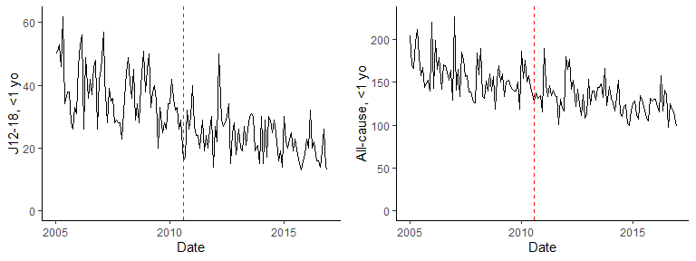

## Fitting a simple linear trend

Here the X variable is time and the y variable is deaths due to J12-18

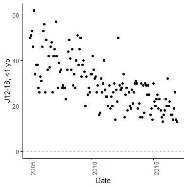

```r
p1 <- ggplot(ds1, aes(x=date, y=J12_J18_prim)) +
      geom_point() +
      ylab("J12-18, <1 yo") +
      xlab("Date") +
      theme_classic() +
      theme(panel.spacing= unit(2,'lines') , axis.text.x=element_text(angle=90)) +
      geom_hline(yintercept=0, col='gray', lty=2)
p1
```

We will use negative binomial regression with these data. For *count* (number of deaths per month), we use either Poisson or negative binomial regression. We could use a Poisson regression, but often the data will be “overdispersed”, and as a result, confidence intervals will be incorrectly tight. You can address this by using either as negative binomial regression, or a quassipoisson model, where you model the amount of unexplained variation

```r
   mod1<-glm.nb(J12_J18_prim~date , data=ds1)
   summary(mod1)
```

```
Call:
glm.nb(formula = J12_J18_prim ~ date, data = ds1, init.theta = 38.18052746,
    link = log)

Deviance Residuals:
     Min        1Q    Median        3Q       Max
-2.19074  -0.76864   0.07023   0.61791   2.97988

Coefficients:
              Estimate Std. Error z value Pr(>|z|)
(Intercept)  6.458e+00  2.427e-01   26.61   <2e-16 ***
date        -2.066e-04  1.637e-05  -12.62   <2e-16 ***
---
Signif. codes:  0 ‘***’ 0.001 ‘**’ 0.01 ‘*’ 0.05 ‘.’ 0.1 ‘ ’ 1

(Dispersion parameter for Negative Binomial(38.1805) family taken to be 1)

    Null deviance: 303.99  on 143  degrees of freedom
Residual deviance: 142.25  on 142  degrees of freedom
AIC: 976.13

Number of Fisher Scoring iterations: 1

              Theta:  38.2
          Std. Err.:  10.2

 2 x log-likelihood:  -970.129
```

extract the fitted values and plot them

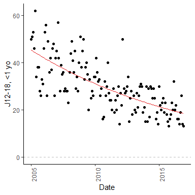

```r
ds1.pred <- cbind.data.frame(ds1,'pred'=predict(mod1,type='response'))

p1 <- ggplot(ds1, aes(x=date, y=J12_J18_prim)) +
      geom_point() +
      ylab("J12-18, <1 yo") +
      xlab("Date") +
      theme_classic() +
      theme(panel.spacing= unit(2,'lines') , axis.text.x=element_text(angle=90)) +
      geom_hline(yintercept=0, col='gray', lty=2) +
      geom_line(color='#e41a1c', data=ds1.pred, aes(x=date, y=pred))

p1
```

#Let’s control for seasonality Use a monthly ‘dummy’ variable that allows each month to have a different average

```r
ds1$month<-as.factor(month(ds1$date)) #create as a factor variable
ds1$month[1:36] #print first 36 observations
```

```
 [1] 1  2  3  4  5  6  7  8  9  10 11 12 1  2  3  4  5  6  7
[20] 8  9  10 11 12 1  2  3  4  5  6  7  8  9  10 11 12
Levels: 1 2 3 4 5 6 7 8 9 10 11 12
```

fit updated model

```r
mod1a<-glm.nb(J12_J18_prim~date +month, data=ds1)
summary(mod1a)
```

```
Call:
glm.nb(formula = J12_J18_prim ~ date + month, data = ds1, init.theta = 88.28907799,
    link = log)

Deviance Residuals:
    Min       1Q   Median       3Q      Max
-2.2301  -0.7018  -0.1246   0.7013   2.7837

Coefficients:
              Estimate Std. Error z value Pr(>|z|)
(Intercept)  6.496e+00  2.156e-01  30.132  < 2e-16 ***
date        -1.988e-04  1.426e-05 -13.941  < 2e-16 ***
month2      -2.717e-02  8.166e-02  -0.333 0.739391
month3       3.446e-02  8.086e-02   0.426 0.669971
month4      -1.892e-01  8.441e-02  -2.241 0.025011 *
month5      -4.964e-02  8.228e-02  -0.603 0.546315
month6      -1.571e-01  8.409e-02  -1.868 0.061714 .
month7      -2.118e-01  8.513e-02  -2.488 0.012840 *
month8      -2.076e-01  8.518e-02  -2.437 0.014804 *
month9      -3.266e-01  8.749e-02  -3.733 0.000189 ***
month10     -2.253e-01  8.574e-02  -2.627 0.008603 **
month11     -2.467e-01  8.626e-02  -2.859 0.004243 **
month12     -3.386e-01  8.813e-02  -3.842 0.000122 ***
---
Signif. codes:  0 ‘***’ 0.001 ‘**’ 0.01 ‘*’ 0.05 ‘.’ 0.1 ‘ ’ 1

(Dispersion parameter for Negative Binomial(88.2891) family taken to be 1)

    Null deviance: 404.40  on 143  degrees of freedom
Residual deviance: 143.84  on 131  degrees of freedom
AIC: 959.32

Number of Fisher Scoring iterations: 1

              Theta:  88.3
          Std. Err.:  41.2

 2 x log-likelihood:  -931.319
```

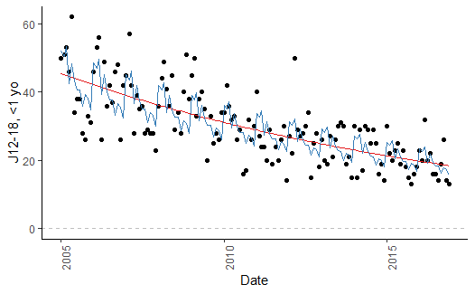

```r
ds1.pred1 <- cbind.data.frame(ds1.pred,'pred2'=predict(mod1a,type='response')) #extract fitted value and add to ds1.pred

p2 <- p1 +
      geom_line(color='#377eb8', data=ds1.pred1, aes(x=date, y=pred2))

p2
```

```r
NA
NA
```

We might want to add an ‘offset’ variable that is used as a denominator. This could be population size; or all-non-respiratory causes of mortality

```r
ds1$log.offset<-log(ds1$acm_noj_prim)
```

refit the model with an offset and look at results

```r
  mod2<-glm.nb(J12_J18_prim~date +month+ offset(log.offset) , data=ds1)
   summary(mod2)
```

```
Call:
glm.nb(formula = J12_J18_prim ~ date + month + offset(log.offset),
    data = ds1, init.theta = 59.07221497, link = log)

Deviance Residuals:
    Min       1Q   Median       3Q      Max
-2.1202  -0.7670  -0.1517   0.6531   3.3006

Coefficients:
              Estimate Std. Error z value Pr(>|z|)
(Intercept)  9.261e-02  2.283e-01   0.406   0.6849
date        -1.146e-04  1.511e-05  -7.583 3.38e-14 ***
month2       1.652e-01  8.737e-02   1.891   0.0587 .
month3       1.508e-01  8.677e-02   1.738   0.0822 .
month4      -6.560e-04  8.995e-02  -0.007   0.9942
month5       7.023e-02  8.809e-02   0.797   0.4253
month6       2.267e-02  8.965e-02   0.253   0.8004
month7      -1.241e-02  9.067e-02  -0.137   0.8911
month8       7.643e-03  9.078e-02   0.084   0.9329
month9      -5.273e-02  9.297e-02  -0.567   0.5706
month10     -5.465e-03  9.126e-02  -0.060   0.9522
month11      4.437e-02  9.166e-02   0.484   0.6283
month12     -2.841e-02  9.353e-02  -0.304   0.7613
---
Signif. codes:  0 ‘***’ 0.001 ‘**’ 0.01 ‘*’ 0.05 ‘.’ 0.1 ‘ ’ 1

(Dispersion parameter for Negative Binomial(59.0722) family taken to be 1)

    Null deviance: 219.57  on 143  degrees of freedom
Residual deviance: 145.49  on 131  degrees of freedom
AIC: 977.6

Number of Fisher Scoring iterations: 1

              Theta:  59.1
          Std. Err.:  21.1

 2 x log-likelihood:  -949.603
```

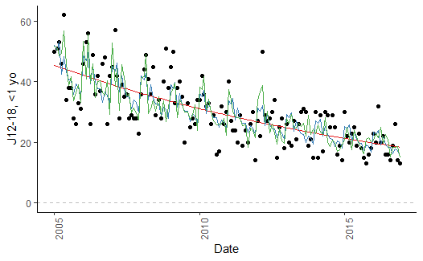

```r
ds1.pred2 <- cbind.data.frame(ds1.pred,'pred3'=predict(mod2,type='response')) #extract fitted value and add to ds1.pred

p3 <- p2+
      geom_line(color='#4daf4a', data=ds1.pred2, aes(x=date, y=pred3))

p3
```

## Now lets test if the trend or level of disease changes

There are 3 ways we can do this. 1. Interrupted time series fits different line segments through the data and tests whether the slope or level of disease changes. This can sometimes result in weird jumps when fitting the model

2. Spline model, which allows the slope to change in the post-vaccine period but forces the change to be smooth
3. Fit the model to the pre-vaccine period only and extrapolate a trend to the post-vaccine period

## Method 1. Interrupted time series

```r
ds1$period1<-0
ds1$period2<-0

ds1$period1[ds1$date>=vax.intro.date]<-1
ds1$period2[ds1$date>=vax.eval.date]<-1

ds1$index<-1:nrow(ds1)
ds1[,c('date','index','period1','period2')]
```

|  | date | index | period1 | period2 |
| --- | --- | --- | --- | --- |
| 12332 | 2005-01-01 | 1 | 0 | 0 |
| 12333 | 2005-02-01 | 2 | 0 | 0 |
| 12334 | 2005-03-01 | 3 | 0 | 0 |
| 12335 | 2005-04-01 | 4 | 0 | 0 |
| 12336 | 2005-05-01 | 5 | 0 | 0 |
| 12337 | 2005-06-01 | 6 | 0 | 0 |
| 12338 | 2005-07-01 | 7 | 0 | 0 |
| 12339 | 2005-08-01 | 8 | 0 | 0 |
| 12340 | 2005-09-01 | 9 | 0 | 0 |
| 12341 | 2005-10-01 | 10 | 0 | 0 |

[output cut: 134 more lines]

Ok, now let’s fit our ITS model and look at results

```r
  mod3<-glm.nb(J12_J18_prim~index +month+
                 period1 +period1*index +
                 period2 +period2*index+ #change in disease during evaluation period
                 offset(log.offset) , data=ds1)
summary(mod3)
```

```
Call:
glm.nb(formula = J12_J18_prim ~ index + month + period1 + period1 *
    index + period2 + period2 * index + offset(log.offset), data = ds1,
    init.theta = 65.62229438, link = log)

Deviance Residuals:
    Min       1Q   Median       3Q      Max
-2.2046  -0.7176  -0.1894   0.6633   3.1605

Coefficients:
               Estimate Std. Error z value Pr(>|z|)
(Intercept)   -1.410897   0.074005 -19.065   <2e-16 ***
index         -0.001660   0.001288  -1.288   0.1976
month2         0.163960   0.085713   1.913   0.0558 .
month3         0.148234   0.085153   1.741   0.0817 .
month4        -0.003138   0.088498  -0.035   0.9717
month5         0.067516   0.086678   0.779   0.4360
month6         0.019034   0.088478   0.215   0.8297
month7        -0.016266   0.089654  -0.181   0.8560
month8         0.003650   0.089526   0.041   0.9675
month9        -0.055524   0.091668  -0.606   0.5447
month10       -0.008492   0.089787  -0.095   0.9247
month11        0.039981   0.090176   0.443   0.6575
month12       -0.032091   0.092017  -0.349   0.7273
period1        0.267869   1.533398   0.175   0.8613
period2       -0.184445   1.541114  -0.120   0.9047
index:period1 -0.006384   0.020854  -0.306   0.7595
index:period2  0.004214   0.020870   0.202   0.8400
---
Signif. codes:  0 ‘***’ 0.001 ‘**’ 0.01 ‘*’ 0.05 ‘.’ 0.1 ‘ ’ 1

(Dispersion parameter for Negative Binomial(65.6223) family taken to be 1)

    Null deviance: 227.08  on 143  degrees of freedom
Residual deviance: 145.13  on 127  degrees of freedom
AIC: 980.44

Number of Fisher Scoring iterations: 1

              Theta:  65.6
          Std. Err.:  25.0

 2 x log-likelihood:  -944.439
```

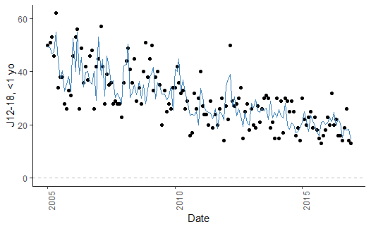

```r
ds.pred.its <- cbind.data.frame(ds1,'pred4'=predict(mod3,type='response')) #extract fitted value and add to ds1.pred

p4 <- ggplot(ds.pred.its, aes(x=date, y=J12_J18_prim)) +
      geom_point() +
      ylab("J12-18, <1 yo") +
      xlab("Date") +
      theme_classic() +
      theme(panel.spacing= unit(2,'lines') , axis.text.x=element_text(angle=90)) +
      geom_hline(yintercept=0, col='gray', lty=2) +
      geom_line(color='#377eb8', data=ds.pred.its, aes(x=date, y=pred4))
p4
```

Now get an estimate for the counterfactual (ie hold vaccine effect to 0 in the model)

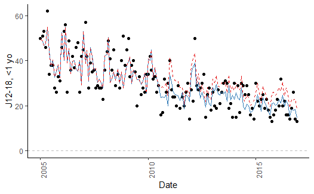

```r
ds1.counterfactual<-ds1
ds1.counterfactual$period1<-0
ds1.counterfactual$period2<-0

ds.pred.its$pred4.cf <- predict(mod3,type='response',newdata=ds1.counterfactual) #extract fitted value and add to ds1.pred

p4 +
 geom_line(color='#e41a1c', lty=2,data=ds.pred.its, aes(x=date, y=pred4.cf))
```

```r
NA
NA
```

Calculate a rate ratio from this model as the ratio of the fitted value and the counterfactual values. We won’t try to estimate a confidence interval here. The InterventionEvaluatR package does this for us automatically.

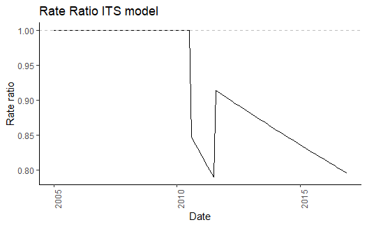

```r
ds.pred.its$rr.its <- ds.pred.its$pred4/ds.pred.its$pred4.cf

p6<- ggplot(ds.pred.its, aes(x=date, y=rr.its)) +
      geom_line() +
      ylab("Rate ratio") +
      xlab("Date") +
       labs(title='Rate Ratio ITS model')+
      theme_classic() +
      theme(panel.spacing= unit(2,'lines') , axis.text.x=element_text(angle=90)) +
      geom_hline(yintercept=1, col='gray', lty=2)

p6
```

## Approach 2: Spline model

In this case, we force the changes to be smooth so that we don’t get the weird jumps like in the ITS example

```r
ds1$index<-1:nrow(ds1)
intro.index<-which(ds1$date==vax.intro.date)
eval.index<-which(ds1$date==vax.eval.date)

ds1$spl1<-ds1$index - intro.index
ds1$spl2<-ds1$index - eval.index
ds1$spl1[ds1$spl1<0]<-0
ds1$spl2[ds1$spl2<0]<-0

ds1[,c('date','index','spl1','spl2')]
```

|  | date | index | spl1 | spl2 |
| --- | --- | --- | --- | --- |
| 12332 | 2005-01-01 | 1 | 0 | 0 |
| 12333 | 2005-02-01 | 2 | 0 | 0 |
| 12334 | 2005-03-01 | 3 | 0 | 0 |
| 12335 | 2005-04-01 | 4 | 0 | 0 |
| 12336 | 2005-05-01 | 5 | 0 | 0 |
| 12337 | 2005-06-01 | 6 | 0 | 0 |
| 12338 | 2005-07-01 | 7 | 0 | 0 |
| 12339 | 2005-08-01 | 8 | 0 | 0 |
| 12340 | 2005-09-01 | 9 | 0 | 0 |
| 12341 | 2005-10-01 | 10 | 0 | 0 |

[output cut: 134 more lines]

Ok, now let’s fit our spline model and look at results

```r
  mod4<-glm.nb(J12_J18_prim~index +month+
                 index+ #trend pre-vaccine
                 spl1+spl2+ #post-vaccine changes
                 offset(log.offset) , data=ds1)
summary(mod4)
```

```
Call:
glm.nb(formula = J12_J18_prim ~ index + month + index + spl1 +
    spl2 + offset(log.offset), data = ds1, init.theta = 60.55043172,
    link = log)

Deviance Residuals:
    Min       1Q   Median       3Q      Max
-2.0228  -0.7679  -0.1944   0.6445   3.2251

Coefficients:
             Estimate Std. Error z value Pr(>|z|)
(Intercept) -1.393266   0.074519 -18.697   <2e-16 ***
index       -0.002527   0.001216  -2.078   0.0377 *
month2       0.164685   0.086971   1.894   0.0583 .
month3       0.151143   0.086358   1.750   0.0801 .
month4      -0.001179   0.089569  -0.013   0.9895
month5       0.069916   0.087696   0.797   0.4253
month6       0.021359   0.089277   0.239   0.8109
month7      -0.013190   0.090295  -0.146   0.8839
month8       0.006758   0.090397   0.075   0.9404
month9      -0.054814   0.092646  -0.592   0.5541
month10     -0.007914   0.090917  -0.087   0.9306
month11      0.041530   0.091346   0.455   0.6494
month12     -0.031677   0.093226  -0.340   0.7340
spl1        -0.006707   0.007049  -0.952   0.3413
spl2         0.006375   0.007329   0.870   0.3844
---
Signif. codes:  0 ‘***’ 0.001 ‘**’ 0.01 ‘*’ 0.05 ‘.’ 0.1 ‘ ’ 1

(Dispersion parameter for Negative Binomial(60.5504) family taken to be 1)

    Null deviance: 221.36  on 143  degrees of freedom
Residual deviance: 145.71  on 129  degrees of freedom
AIC: 980.66

Number of Fisher Scoring iterations: 1

              Theta:  60.6
          Std. Err.:  22.0

 2 x log-likelihood:  -948.663
```

Get fitted and counterfactual for the spline model

```r
 ds.pred.spl<-cbind.data.frame( ds1,'pred.spl'=predict(mod4, type='response') )

ds1.counterfactual.spl<-ds1
ds1.counterfactual.spl$spl1<-0
ds1.counterfactual.spl$spl2<-0

ds.pred.spl$pred.spl.cf <-predict(mod4, type='response', newdata=ds1.counterfactual.spl)
```

The red is counterfactual, blue is fitted

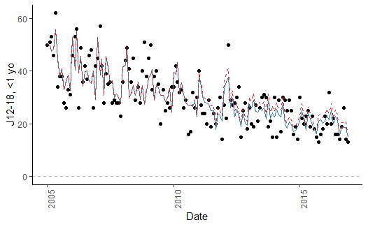

```r
p7 <- ggplot(ds.pred.spl, aes(x=date, y=J12_J18_prim)) +
      geom_point() +
      ylab("J12-18, <1 yo") +
      xlab("Date") +
      theme_classic() +
      theme(panel.spacing= unit(2,'lines') , axis.text.x=element_text(angle=90)) +
      geom_hline(yintercept=0, col='gray', lty=2) +
      geom_line(color='#377eb8', data=ds.pred.spl, aes(x=date, y=pred.spl)) +
       geom_line(color='#e41a1c', lty=2,data=ds.pred.spl, aes(x=date, y=pred.spl.cf))
p7
```

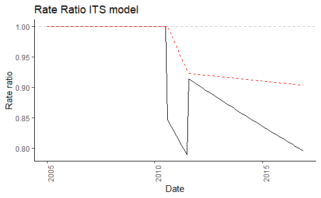

```r
ds.pred.spl$rr.spline <- ds.pred.spl$pred.spl/ds.pred.spl$pred.spl.cf

p8 <- p6 +
     geom_line(color='red', lty=2,data=ds.pred.spl, aes(x=date, y=rr.spline))

p8
```

```r
NA
NA
NA
```

## Approach #3: Fit to pre-vaccine period and extrapolate

First set the pneumonia variable to NA during the post-vaccine period

```r
ds1$J12_J18_prim_pre <- ds1$J12_J18_prim
ds1$J12_J18_prim_pre[which(ds1$date>=vax.intro.date)] <- NA
ds1[,c('date','J12_J18_prim_pre' )]
```

|  | date | J12_J18_prim_pre |
| --- | --- | --- |
| 12332 | 2005-01-01 | 50 |
| 12333 | 2005-02-01 | 51 |
| 12334 | 2005-03-01 | 53 |
| 12335 | 2005-04-01 | 46 |
| 12336 | 2005-05-01 | 62 |
| 12337 | 2005-06-01 | 34 |
| 12338 | 2005-07-01 | 38 |
| 12339 | 2005-08-01 | 38 |
| 12340 | 2005-09-01 | 28 |
| 12341 | 2005-10-01 | 26 |

[output cut: 134 more lines]

```r
mod5<- glm.nb(J12_J18_prim_pre~  index #time trend
              +month #seasonality
              +offset(log.offset), data=ds1)
```

```r
ds.pred.mod5<-cbind.data.frame(ds1, 'pred.mod5'=predict(mod5,type='response', newdata=ds1))
```

Plot the observed and extrapolated data. Note that here the comparison is the *observed* data with the model estimate extrapolated from the pre-vaccine period. This is different form the previous models where we were just comparing the model fitted value with the model fitted value with the vaccine-effects held to 0.

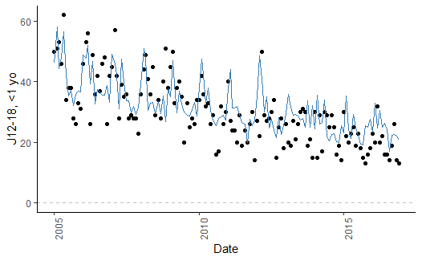

```r
p9 <- ggplot(ds.pred.mod5, aes(x=date, y=J12_J18_prim)) +
      geom_point() +
      ylab("J12-18, <1 yo") +
      xlab("Date") +
      theme_classic() +
      theme(panel.spacing= unit(2,'lines') , axis.text.x=element_text(angle=90)) +
      geom_hline(yintercept=0, col='gray', lty=2) +
      geom_line(color='#377eb8', data=ds.pred.mod5, aes(x=date, y=pred.mod5))
p9
```

```r
ds.pred.mod5$rr.trend<-ds1$J12_J18_prim/ds.pred.mod5$pred.mod5
```

##Let’s compare the rate ratio estimates from the 3 models

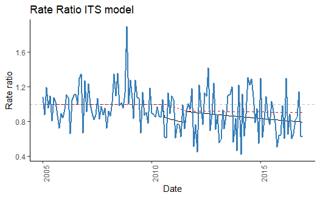

```r
p8 +  geom_line(color='#377eb8',lwd=1, lty=1,data=ds.pred.mod5, aes(x=date, y=rr.trend))
```

## look at rate ratio during the evaluation period

As a rough estimate of this, let’s just average the point-by-point estimates of the rate ratio during the evaluation period.

```r
eval.period<-ds1$date> vax.eval.date

rr.its.eval<- mean(ds.pred.its$rr.its[eval.period])
rr.spline.eval<- mean(ds.pred.spl$rr.spline[eval.period])
rr.trend.eval<- sum(ds.pred.mod5$J12_J18_prim[eval.period])/sum(ds.pred.mod5$pred.mod5[eval.period])

c('ITS'=rr.its.eval,'Spline'=rr.spline.eval,'Trend Extrapolation'=rr.trend.eval )
```

```
                ITS              Spline Trend Extrapolation
          0.8522989           0.9127796           0.8558597
```

*Depending on the dataset, these 3 methods might or might not agree*